# P2 Segunda entrega: Informe

### Integrantes:

- Becerra Ormaeche, Adrián David
- Chávez Aymé, Anthony
- Zúñiga Nole, Gilmar Gerard (Líder)

## Relevancia del estudio

La música es gran parte de las tendencias culturales a nivel mundial, nuestro objetivo con este proyecto es entender y analizar estas tendencias de popularidad y descubrir qué características comparten las canciones más populares en los Top 200 Weekly (Global) de Spotify (2017 - 2021), comprender qué géneros musicales son los más escuchados, definir un modelo de aprendizaje automático. Se buscará conseguir información que será de interés para la audiencia y obtener diversas conclusiones al finalizar este estudio estadístico, como, por ejemplo:

- Establecer relaciones entre el ranking de una determinada canción y los streams de esta
- Responder a la pregunta: ¿A mayor duración de la canción, esta esta será más exitosa?
- La canción más escuchada, el artista que la compuso, género al que pertenece, etc.
- Ver la evolución de determinados artistas conforme han escalado en el ranking

**Todo este estudio se realizará en base a la data y en el periodo de tiempo propuesto (2017 -2021)**

## Proveniencia de los datos

Para realizar el estudio, utilizaremos las siguientes bases de datos y extensiones:

- Spotify Top 200 Charts Global (2017-2021) + Datos de API, esta data incluye las 200 mejores canciones de Global semanalmente de Spotify (https://www.kaggle.com/bartomiejczyewski/spotify-top-200-weekly-global-20172021)
- Listas top 200 de Spotify (2020-2021), esta data incluye todas las canciones que han estado en las listas Top 200 Weekly (Global) de Spotify en 2020 y 2021 (https://www.kaggle.com/sashankpillai/spotify-top-200-charts-20202021)
- Spotify Charts (https://spotifycharts.com/regional/global/weekly/latest)
- API de Spotify (https://api.spotify.com/)
- Spotipy Python Library (https://spotipy.readthedocs.io/en/2.19.0/)

## Disponibilidad de los datos

Spotify, al ser una empresa con estadísticas libres, mediante la API de Spotify y Spotify Charts pudimos tener acceso a suficiente data para hacer factible nuestro estudio y, además, mediante diversas páginas y extensiones como Kaggle, Spotipy Python Library, etc. complementamos la data proporcionada por Spotify.

```r
# Carga de data

library (readr)
library (dplyr)
library (stringr)
R <- read_csv ("Spotify Top 200 Global (2017-2021).csv")
# Limpieza de data

R$Link <- NULL
R %>% rename (Duration_Minutos = Duration_MS) -> R
R$Duration_Minutos <- R$Duration_Minutos / (1000 * 60)
R$Artist_Genres [R$Artist_Genres == "[]"] <- NA

# Declarado de funciones

Describir <- function(X, ...){
  cat("Promedio:", mean(X, ...), "\n\n")
  cat("Mediana:", median(X, ...), "\n\n")
  cat ("Nº de modas:", length (table(X)[table(X) == max(table(X))]), "\n\n")
  cat("Desviación estándar:", sd(X, ...), "\n\n")
  cat("Rango:"
      , max(X, ...) - min(X, ...)
      , "\n\n")
  cat("Rango intercuartil:"
      , quantile(X, ..., 0.75)
      - quantile(X, ..., 0.25)
      , "\n")
  cat ("\nCuartiles\n\n",
       "1.º Cuartil:", quantile(X, ..., 0.25), "\n",
       "2.º Cuartil:", quantile(X, ..., 0.5), "\n",
       "3.º Cuartil:", quantile(X, ..., 0.75), "\n",
       "4.º Cuartil:", quantile(X, ..., 1), "\n\n")
  cat("Mínimo:", min(X, ...), "\n\n")
  cat("Máximo:", max(X, ...), "\n\nModa:\n")
  table(X)[table(X) == max(table(X))]
}
```

```r
summary (R)
```

```
      Rank           Track              Artist             Streams              Week             Album_Name        Duration_Minutos  Explicit
 Min.   :  1.00   Length:44200       Length:44200       Min.   : 2525159   Min.   :2017-01-06   Length:44200       Min.   :0.5022   Mode :logical
 1st Qu.: 50.75   Class :character   Class :character   1st Qu.: 4921200   1st Qu.:2018-02-09   Class :character   1st Qu.:3.0319   FALSE:27684
 Median :100.50   Mode  :character   Mode  :character   Median : 6290181   Median :2019-03-01   Mode  :character   Median :3.4058   TRUE :16516
 Mean   :100.50                                         Mean   : 8350751   Mean   :2019-02-27                      Mean   :3.4499
 3rd Qu.:150.25                                         3rd Qu.: 9612882   3rd Qu.:2020-03-20                      3rd Qu.:3.7913
 Max.   :200.00                                         Max.   :80764045   Max.   :2021-04-16                      Max.   :9.6200
 Track_Number_on_Album Artist_Followers   Artist_Genres
 Min.   : 1.000        Min.   :       9   Length:44200
 1st Qu.: 1.000        1st Qu.: 3963838   Class :character
 Median : 2.000        Median :10653835   Mode  :character
 Mean   : 4.035        Mean   :17239028
 3rd Qu.: 6.000        3rd Qu.:26792113
 Max.   :76.000        Max.   :78967872
```

# Consideraciones para la realización del estudio

Procesamos, limpiamos y reparamos correctamente errores en la **data inicial** proporcionada por Spotify, definimos y clasificamos **11** variables relevantes para el estudio:

- La variable Duration_MS, que mide la duración de la canción en mili segundos, fue re definida correctamente de la data inicial al ser transformada a minutos (divida por (1000 * 60)) y su nombre cambiado a Duration_Minutos. Se realizó este cambio,dado que, la mayoría de canciones tienen tiempo de duración medido en minutos y es mucho más usual en los usuarios.
- La variable Link fue eliminada de la data inicial, dado que, son datos que no proporcionan información relevante para el análisis realizado en el estudio.
- La variable Artist_Genres, que muestra una lista de strings con los géneros del artista, posee datos de la forma “[]”, indicándonos una lista vacía y que dicho artista no tiene géneros asociados a sus canciones. Es por ello que como grupo, tomamos la decisión de asignar a dicha lista vacía el valor de NA.

**No se realizó en ningún momento manipulación de la data proporcionada por Spotify, asegurando así, la ética académica y profesional en la realización del presente estudio**

# Análisis de data

```r
cat("Nº de observaciones o tamaño de la muestra:", nrow (R), "\n\nNº de observaciones completas o tamaño efectivo de la muestra:", nrow (R) - sum (is.na (R$Track)) - sum (is.na (R$Artist_Genres) & !is.na(R$Track)), "\n\nNº de datos faltantes:", sum (is.na (R$Track)) + sum (is.na (R$Artist)) + sum (is.na (R$Album_Name)) + sum (is.na (R$Artist_Genres)), "(5 datos en Track, 5 datos en Artist, 5 datos en Album_Name y 156 en Artist_Genres)", "\n\nNº de variables:", ncol (R))
```

```
Nº de observaciones o tamaño de la muestra: 44200

Nº de observaciones completas o tamaño efectivo de la muestra: 44044

Nº de datos faltantes: 171 (5 datos en Track, 5 datos en Artist, 5 datos en Album_Name y 156 en Artist_Genres)

Nº de variables: 11
```

En las siguientes tablas podemos observar las **observaciones incompletas** y los **datos faltantes**:

```r
R %>% filter (is.na (Track))
```

| Rank | Track | Artist | Streams | Week | Album_Name | Duration_Minutos | Explicit | Track_Number_on_Album | Artist_Followers | Artist_Genres |
| --- | --- | --- | --- | --- | --- | --- | --- | --- | --- | --- |
| 4 | NA | NA | 25442248 | 2017-07-21 | NA | 3.249617 | FALSE | 7 | 1145053 | NA |
| 10 | NA | NA | 20049646 | 2017-07-21 | NA | 3.102900 | FALSE | 2 | 1145053 | NA |
| 30 | NA | NA | 12964826 | 2017-07-21 | NA | 3.578333 | FALSE | 6 | 1145053 | NA |
| 40 | NA | NA | 10766506 | 2017-07-21 | NA | 3.680650 | FALSE | 10 | 1145053 | NA |
| 32 | NA | NA | 10597738 | 2017-11-10 | NA | 3.172133 | TRUE | 2 | 1145053 | NA |

```r
R %>% filter (is.na (Artist_Genres) & !is.na (Track))
```

| Rank | Track | Artist | Streams | Week | Album_Name | Duration_Minutos | Explicit | Track_Number_on_Album | Artist_Followers | Artist_Genres |
| --- | --- | --- | --- | --- | --- | --- | --- | --- | --- | --- |
| 90 | Juju on That Beat (TZ Anthem) | Zay Hilfigerrr | 4580028 | 2017-01-06 | Juju on That Beat (TZ Anthem) | 2.4040667 | FALSE | 1 | 62682 | NA |
| 165 | Oh Lord | MiC LOWRY | 2991349 | 2017-01-06 | Oh Lord | 3.5790667 | FALSE | 1 | 44401 | NA |
| 109 | Juju on That Beat (TZ Anthem) | Zay Hilfigerrr | 4003507 | 2017-01-13 | Juju on That Beat (TZ Anthem) | 2.4040667 | FALSE | 1 | 62682 | NA |
| 159 | Oh Lord | MiC LOWRY | 3106807 | 2017-01-13 | Oh Lord | 3.5790667 | FALSE | 1 | 44401 | NA |
| 130 | Juju on That Beat (TZ Anthem) | Zay Hilfigerrr | 3782977 | 2017-01-20 | Juju on That Beat (TZ Anthem) | 2.4040667 | FALSE | 1 | 62682 | NA |
| 142 | Oh Lord | MiC LOWRY | 3504674 | 2017-01-20 | Oh Lord | 3.5790667 | FALSE | 1 | 44401 | NA |
| 170 | Romantic - NOTD Remix | Stanaj | 3011862 | 2017-01-20 | From A Distance | 3.0806667 | FALSE | 5 | 59603 | NA |
| 136 | Romantic - NOTD Remix | Stanaj | 3650171 | 2017-01-27 | From A Distance | 3.0806667 | FALSE | 5 | 59603 | NA |
| 151 | Juju on That Beat (TZ Anthem) | Zay Hilfigerrr | 3241682 | 2017-01-27 | Juju on That Beat (TZ Anthem) | 2.4040667 | FALSE | 1 | 62682 | NA |
| 165 | Oh Lord | MiC LOWRY | 3068806 | 2017-01-27 | Oh Lord | 3.5790667 | FALSE | 1 | 44401 | NA |

[output cut: 141 more lines]

# Variables

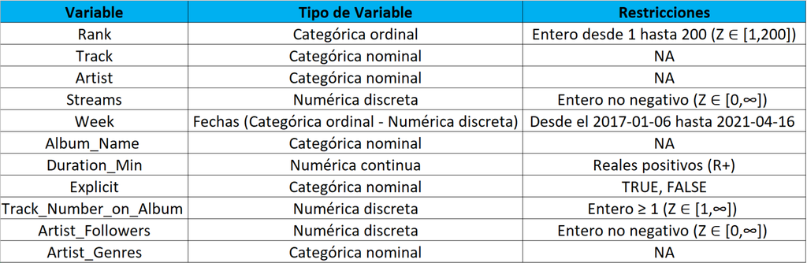

## Representatividad de las variables

- **Rank:** Ranking (posición) de una canción en las 200 mejores canciones de Global semanal de Spotify (Spotify Top 200 Charts Weekly Global (2017-2021))
- **Track:** Nombre de la canción (pista)
- **Artist:** Nombre del artista
- **Streams:** Transmisiones o vistas de una canción en una semana determinada
- **Week:** Último día de una semana del top semanal
- **Album_Name :** Nombre del álbum
- **Duration_Minutos:** Duración en minutos
- **Explicit:** ¿Es la canción Explicit?
- **Track_Number_on_Album :** Número de pista en el álbum
- **Artist_Followers:** Número de seguidores del artista
- **Artist_Genres:** Géneros del artista

# Descriptores de Interacción

```r
smoothScatter(R$Rank,
              (R$Streams /1000000),
              pch = 20,
              col = rgb(0, 0, 0, 0.2),
              main = "Diagrama de dispersión",
              xlab = "Ranking del 1 al 200",
              ylab = "Streams (millones)",
              sub = paste(sum (!is.na (R$Rank)), "observaciones de una muestra de", nrow (R))
              )
points (mean(R$Rank, na.rm = TRUE),
        mean((R$Streams /1000000), na.rm = TRUE),
        pch = 20,
        col = "green"
        )
```

```r
abline (h = mean((R$Streams /1000000), na.rm = TRUE),
        lty = 2,
        col = "black"
        )
abline (lm((R$Streams /1000000) ~ R$Rank),
        col = "green",
        lty = 1
        )
```

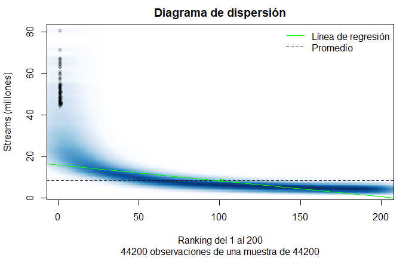

```r
legend("topright",
       legend = c ("Línea de regresión", "Promedio"),
       col = c ("green", "black"),
       lty = c (1, 2),
       bty = "n"
       )
```

```r
cat ("Promedio de streams en la data (millones):",
      mean ((R$Streams /1000000)),
     "\n\nCorrelación Streams ~ Rank:",
      cor(R$Streams,
          R$Rank, use = "complete.obs")
     )
```

```
Promedio de streams en la data (millones): 8.350751

Correlación Streams ~ Rank: -0.75716
```

La gráfica **“Streams vs Rank”** nos muestra una relación o tendencia inversa (inversamente proporcional), con aproximación logarítmica. Vemos que conforme el ranking de una canción “aumenta” (disminuye en los Spotify Top 200 Charts Weekly Global (2017-2021)), el Nº de streams de una canción disminuye.

El coeficiente de correlación **“Streams ~ Rank”**, el cual mide el grado de asociación lineal, tiene un valor de -0.757161 (pendiente negativa en línea de regresión), sin embargo, podemos notar que dichos datos no están relacionados linealmente. La línea de regresión no describe el conjunto de datos, es decir, el coeficiente de correlación falla al querer capturar el comportamiento de los datos.

```r
smoothScatter(R$Rank,
              R$Duration_Minutos,
              pch = 20,
              col = rgb(0, 0, 0, 0.2),
              main = "Diagrama de dispersión",
              xlab = "Ranking del 1 al 200",
              ylab = "Duración de canciones (minutos)",
              sub = paste(sum (!is.na (R$Rank)), "observaciones de una muestra de", nrow (R))
              )
abline(h = mean(R$Duration_Minutos, na.rm = TRUE),
       lty = 2,
       col = "green"
       )
```

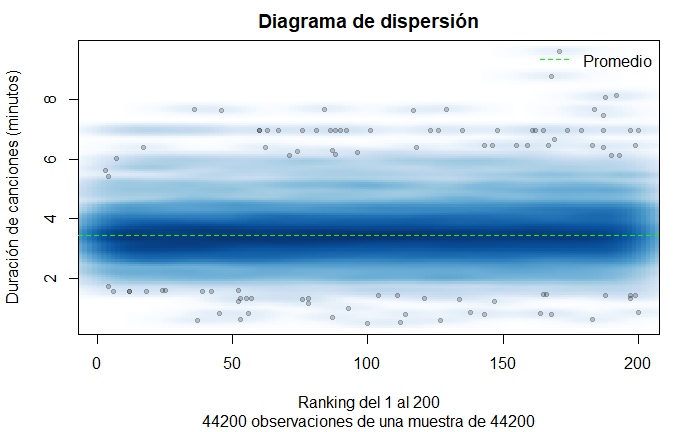

```r
legend("topright",
       legend = c ("Promedio"),
       col = c ("green"),
       lty = c (2),
       bty = "n"
       )
```

```r
cat ("Promedio de duración de canciones en la data (minutos):", mean (R$Duration_Minutos ))
```

```
Promedio de duración de canciones en la data (minutos): 3.449862
```

La gráfica **“Duración vs Rank”** nos muestra una aglomeración de data (canciones) con intensidad oscura entre los minutos 2 y 4, esto quiere decir, que la mayoría de canciones que han ocupado un puesto en los Spotify Top 200 Charts Weekly Global (2017-2021) han tenido una duración de entre 2 y 4 minutos, siendo el promedio de la duración de canciones en la data (minutos): 3.449862.

```r
plot((R$Streams / 1000000),
     R$Duration_Minutos,
     pch = 20,
     col = rgb(0, 0, 0, 0.2),
     main = "Diagrama de dispersión",
     xlab = "Streams (millones)",
     ylab = "Duración de canciones (minutos)",
     sub = paste(sum (!is.na (R$Streams)), "observaciones de una muestra de", nrow (R))
     )
points(mean((R$Streams / 1000000), na.rm = TRUE),
       mean(R$Duration_Minutos, na.rm = TRUE),
       pch = 20,
       col = "green"
       )
```

```r
abline(h = mean(R$Duration_Minutos, na.rm = TRUE),
       lty = 2,
       col = "green"
       )
abline(v = mean((R$Streams / 1000000), na.rm = TRUE),
       lty = 2,
       col = "green"
       )
```

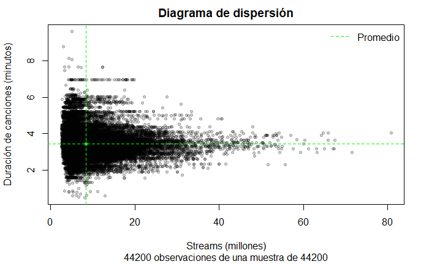

```r
legend("topright",
       legend = c ("Promedio"),
       col = c ("green"),
       lty = c (2),
       bty = "n"
       )
```

```r
cat ("Promedio de duración de canciones en la data (minutos):", mean (R$Duration_Minutos), "\n\nPromedio de streams en la data (millones):", mean ((R$Streams / 1000000), na.rm = TRUE))
```

```
Promedio de duración de canciones en la data (minutos): 3.449862

Promedio de streams en la data (millones): 8.350751
```

La gráfica **“Duración vs Streams”** nos muestra una aglomeración de data (canciones) con intensidad oscura que comienza entre los minutos 2 y 6, y va convergiendo conforme el tiempo de duración de una canción se acerca al promedio y el Nº de streams de una canción va aumentando. Esto quiere decir, que las canciones con mayor Nº de streams (han ocupado un puesto alto en los Spotify Top 200 Charts Weekly Global (2017-2021)) tienden a tener una duración muy cercana al promedio de la duración de canciones en la data: 3.449862 (minutos).

## Canciones en los rankings 1, 100 y 200

```r
op <- par(mfrow = c(1, 3))
boxplot (R$Duration_Minutos[R$Rank==1],
         varwidth = TRUE,
         border = rgb (0, 0, 0, 0.2),
         pch = 20,
         main = "Rank 1",
         ylab="Duración de canciones en minutos"
         )
abline (h=mean(R$Duration_Minutos[R$Rank==1]),
        col = c ("blue"),
        lty = c (1)
        )
```

```r
legend("bottomleft",
       legend = c ("Promedio"),
       col = c ("blue"),
       lty = c (1),
       bty = "n"
       )

boxplot (R$Duration_Minutos[R$Rank==100],
         varwidth = TRUE,
         border = rgb (0, 0, 0, 0.2),
         pch = 20,
         main = "Rank 100",
         ylab="Duración de canciones en minutos"
         )
```

```r
abline (h=mean(R$Duration_Minutos[R$Rank==100]),
        col = c ("blue"),
        lty = c (1)
        )
legend("bottomleft",
       legend = c ("Promedio"),
       col = c ("blue"),
       lty = c (1),
       bty = "n"
       )
```

```r
boxplot (R$Duration_Minutos[R$Rank==200],
         varwidth = TRUE,
         border = rgb (0, 0, 0, 0.2),
         pch = 20,
         main = "Rank 200",
         ylab="Duración de canciones en minutos"
         )
abline (h=mean(R$Duration_Minutos[R$Rank==200]),
        col = c ("blue"),
        lty = c (1)
        )
```

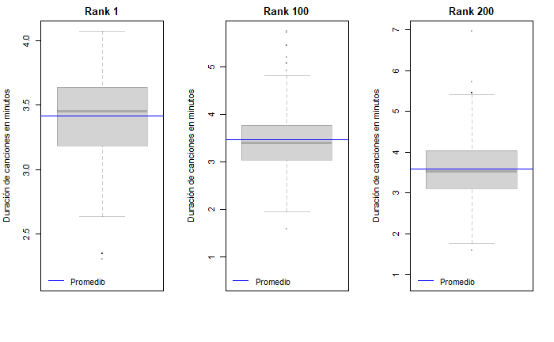

```r
legend("bottomleft",
       legend = c ("Promedio"),
       col = c ("blue"),
       lty = c (1),
       bty = "n"
       )
par(op)
```

En los gráficos presentes, podemos observar que la mayoría de canciones con **ranking 1, 100 y 200** en los Top 200 Charts Weekly Global (2017-2021), poseen una duración de entre 3 y 4 minutos.

```r
plot(R$Week [R$Rank == 1],
     (R$Streams [R$Rank == 1] / 1000000),
     pch = 20,
     col = rgb(0, 0, 0, 0.2),
     main = "Canciones con ranking 1 en la data",
     xlab = "Tiempo (años)",
     ylab = "Streams (millones)",
     sub = paste(sum (!is.na (R$Week [R$Rank == 1])), "observaciones de una muestra de", nrow (R))
     )
abline(h = mean((R$Streams [R$Rank == 1] / 1000000), na.rm = TRUE),
       lty = 2,
       col = "blue"
       )
```

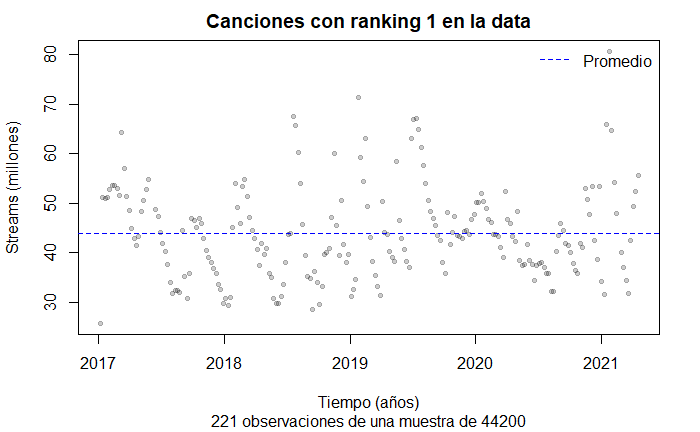

```r
legend("topright",
       legend = c ("Promedio"),
       col = c ("blue"),
       lty = c (2),
       bty = "n"
       )
```

```r
plot(R$Week [R$Rank == 100],
     (R$Streams [R$Rank == 100] / 1000000),
     pch = 20,
     col = rgb(0, 0, 0, 0.2),
     main = "Canciones con ranking 100 en la data",
     xlab = "Tiempo (años)",
     ylab = "Streams (millones)",
     sub = paste(sum (!is.na (R$Week [R$Rank== 100])), "observaciones de una muestra de", nrow (R))
     )
points(mean(R$Week [R$Rank == 100], na.rm = TRUE),
       mean((R$Streams [R$Rank == 100] / 1000000), na.rm = TRUE),
       pch = 20,
       col = "green"
       )
```

```r
abline(h = mean((R$Streams [R$Rank == 100] / 1000000), na.rm = TRUE),
       lty = 2,
       col = "blue"
       )
abline(lm( (R$Streams [R$Rank == 100] / 1000000) ~ R$Week [R$Rank == 100]),
       col = "green"
       )
```

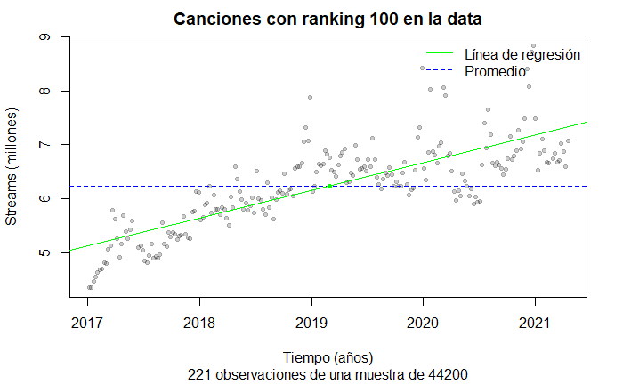

```r
legend("topright",
       legend = c ("Línea de regresión", "Promedio"),
       col = c ("green", "blue"),
       lty = c (1, 2),
       bty = "n"
       )
```

```r
plot(R$Week [R$Rank == 200],
     (R$Streams [R$Rank == 200] / 1000000),
     pch = 20,
     col = rgb(0, 0, 0, 0.2),
     main = "Canciones con ranking 200 en la data",
     xlab = "Tiempo (años)",
     ylab = "Streams (millones)",
     sub = paste(sum (!is.na (R$Week [R$Rank == 200])), "observaciones de una muestra de", nrow (R))
     )
points(mean(R$Week [R$Rank == 200], na.rm = TRUE),
       mean((R$Streams [R$Rank == 200] / 1000000), na.rm = TRUE),
       pch = 20,
       col = "green"
       )
```

```r
abline(h = mean((R$Streams [R$Rank == 200] / 1000000), na.rm = TRUE),
       lty = 2,
       col = "blue"
       )
abline(lm( (R$Streams [R$Rank == 200] / 1000000) ~ R$Week [R$Rank == 200]),
       col = "green"
       )
```

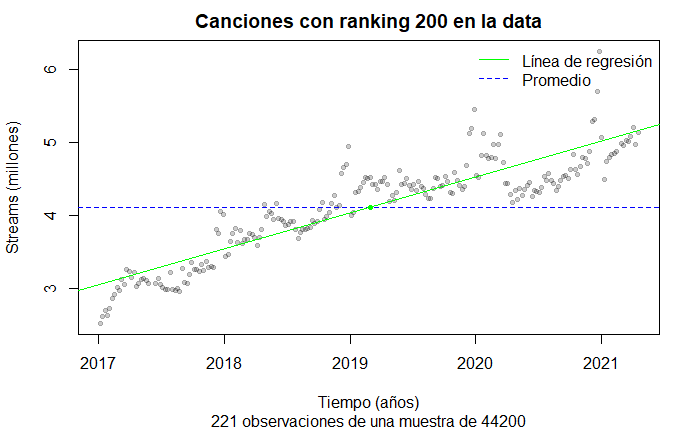

```r
legend("topright",
       legend = c ("Línea de regresión", "Promedio"),
       col = c ("green", "blue"),
       lty = c (1, 2),
       bty = "n"
       )
```

```r
plot(R$Rank [R$Rank == 1 | R$Rank == 100 | R$Rank == 200],
    (R$Streams [R$Rank == 1 | R$Rank == 100 | R$Rank == 200] / 1000000),
     pch = 20,
     col = rgb(0, 0, 0, 0.2),
     main = "Canciones con ranking 1, 100 Y 200 en la data",
     xlab = "Ranking del 1 al 200",
     ylab = "Streams (millones)",
     sub = paste(sum (!is.na (R$Rank [R$Rank == 1 | R$Rank == 100 | R$Rank == 200])), "observaciones de una muestra de", nrow (R))
     )
abline(h = mean((R$Streams [R$Rank == 1 | R$Rank == 100 | R$Rank == 200] / 1000000), na.rm = TRUE),
       lty = 2,
       col = "blue"
       )
```

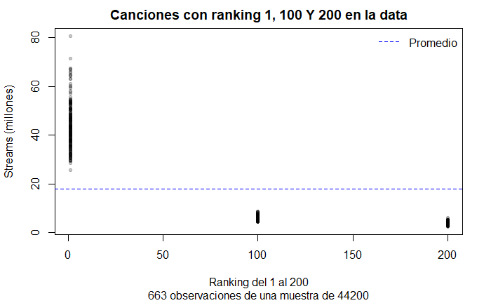

```r
legend("topright",
       legend = c ("Promedio"),
       col = c ("blue"),
       lty = c (2),
       bty = "n"
       )
```

En el gráfico **“Canciones con ranking 1, 100 Y 200 en la data”** se observa el Nº de streams de aquellas canciones con rankings 1, 100 y 200 en los Top 200 Charts Weekly Global. Notamos que aquellas canciones que ocuparon el **ranking 1** tienen un Nº de streams mucho mayor que aquellas canciones que ocuparon el **ranking 100 y 200**. Como se mencionó en el gráfico anterior, para ocupar **rankings superiores** se necesita un mucho mayor Nº de streams.

```r
plot(R$Week [R$Rank == 1],
     R$Track_Number_on_Album [R$Rank == 1],
     pch = 20,
     col = rgb(0, 0, 0, 0.2),
     main = "Canciones con ranking 1 en la data",
     xlab = "Tiempo (años)",
     ylab = "Nº de pista en el álbum",
     sub = paste(sum (!is.na (R$Week [R$Rank == 1])), "observaciones de una muestra de", nrow (R))
     )
abline (h = min (R$Track_Number_on_Album),
        lty = 2,
        col = "green")
```

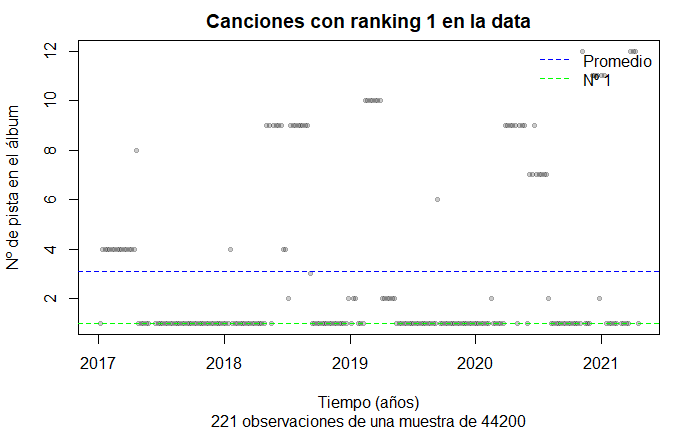

```r
abline(h = mean(R$Track_Number_on_Album [R$Rank == 1], na.rm = TRUE),
       lty = 2,
       col = "blue"
       )
legend("topright",
       legend = c ("Promedio", "Nº 1"),
       col = c ("blue", "green"),
       lty = c (2, 2),
       bty = "n"
       )
```

```r
plot(R$Week [R$Rank == 100],
     R$Track_Number_on_Album [R$Rank == 100],
     pch = 20,
     col = rgb(0, 0, 0, 0.2),
     main = "Canciones con ranking 100 en la data",
     xlab = "Tiempo (años)",
     ylab = "Nº de pista en el álbum",
     sub = paste(sum (!is.na (R$Week [R$Rank == 100])), "observaciones de una muestra de", nrow (R))
     )
abline (h = min (R$Track_Number_on_Album),
        lty = 2,
        col = "green")
```

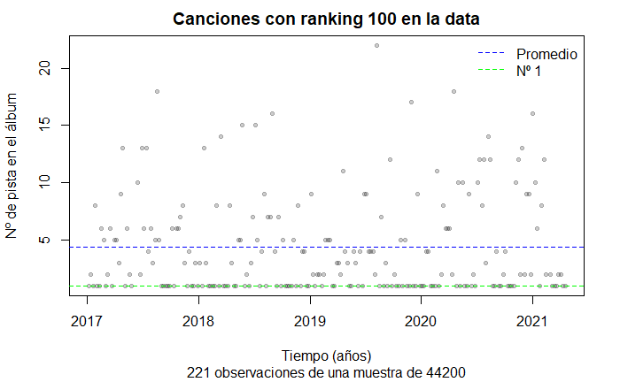

```r
abline(h = mean(R$Track_Number_on_Album [R$Rank == 100], na.rm = TRUE),
       lty = 2,
       col = "blue"
       )
legend("topright",
       legend = c ("Promedio", "Nº 1"),
       col = c ("blue", "green"),
       lty = c (2, 2),
       bty = "n"
       )
```

```r
plot(R$Week [R$Rank == 200],
     R$Track_Number_on_Album [R$Rank == 200],
     pch = 20,
     col = rgb(0, 0, 0, 0.2),
     main = "Canciones con ranking 200 en la data",
     xlab = "Tiempo (años)",
     ylab = "Nº de pista en el álbum",
     sub = paste(sum (!is.na (R$Week [R$Rank == 200])), "observaciones de una muestra de", nrow (R))
     )
abline (h = min (R$Track_Number_on_Album),
        lty = 2,
        col = "green")
```

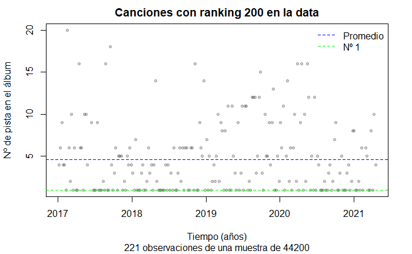

```r
abline(h = mean(R$Track_Number_on_Album [R$Rank == 200], na.rm = TRUE),
       lty = 2,
       col = "blue"
       )
legend("topright",
       legend = c ("Promedio", "Nº 1"),
       col = c ("blue", "green"),
       lty = c (2, 2),
       bty = "n"
       )
```

En los gráficos **“Canciones con ranking 1, 100 y 200 en la data”**, podemos observar que aquellas canciones que han obtenido el **ranking 1, 100 o 200** en los Top 200 Charts Weekly Global (2017-2021), tienden a ser aquellas canciones con número de pista **“1”** en sus álbumes correspondientes. Se podría decir que los artistas al lanzar sus álbumes, tienden a poner como 1° canción, aquella que consideren que será un éxito en los Top.

**Esta conclusión, debe estar sujeta a muchos más análisis** en la gráfica **Canciones con ranking 1**, dado que, la gráfica es potencialmente engañosa. Un álbum tiene un Nº canciones relativamente pequeño y todos los álbumes tienen pista Nº 1; puede que en la gráfica lo que estamos viendo sean pocas canciones que se mantienen por un tiempo en la posición Nº 1, por eso podemos observar escalones relativamente anchos en la gráfica. Este fenómeno no se observa en las gráficas de los **rankings 100 y 200** debido a que las canciones intercambian posiciones en su fase de subida y bajada de popularidad.

```r
op <- par (mfrow = c (1, 2))
barplot(table(R$Explicit),
        pch = 20,
        col = "lightblue",
        main="Canciones Explicit en la data",
        ylab="Frecuencia relativa",
        sub = paste(sum (!is.na (R$Explicit)), "observaciones de una muestra de", nrow (R))
        )
barplot(table(R$Explicit [R$Rank==1]),
        pch = 20,
        col = "lightblue",
        main="Explicit ranking 1 en la data",
        ylab="Frecuencia relativa",
        sub = paste(sum (!is.na (R$Explicit [R$Rank==1])), "observaciones de una muestra de", nrow (R))
        )
```

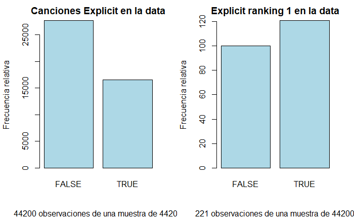

```r
par (op)

op <- par (mfrow = c (1, 2))
```

```r
barplot(table(R$Explicit [R$Rank==100]),
        pch = 20,
        col = "lightblue",
        main="Explicit ranking 100 en la data",
        ylab="Frecuencia relativa",
        sub = paste(sum (!is.na (R$Explicit [R$Rank==100])), "observaciones de una muestra de", nrow (R))
        )
barplot(table(R$Explicit [R$Rank==200]),
        pch = 20,
        col = "lightblue",
        main="Explicit ranking 200 en la data",
        ylab="Frecuencia relativa",
        sub = paste(sum (!is.na (R$Explicit [R$Rank==200])), "observaciones de una muestra de", nrow (R))
        )
```

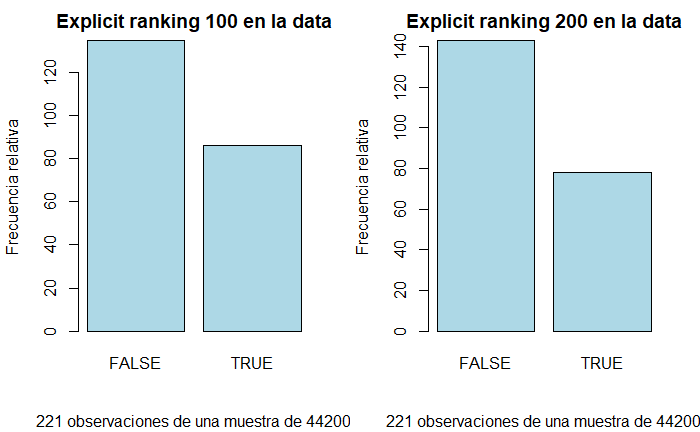

```r
par (op)
```

- En el 1.º gráfico **Canciones Explicit en la data**, se observa que la mayoría de canciones en los Spotify Top 200 Charts Weekly Global (2017-2021) **no** posee clasificación Explicit.
- En el 2.º gráfico **Canciones Explicit con ranking 1 en la data**, se observa que la mayoría de canciones en los Spotify Top 200 Charts Weekly Global (2017-2021) **sí** posee clasificación Explicit.
- En el 3.º gráfico **Canciones Explicit con ranking 100 en la data**, se observa que la mayoría de canciones en los Spotify Top 200 Charts Weekly Global (2017-2021) **no** posee clasificación Explicit.
- En el 4.º gráfico **Canciones Explicit con ranking 200 en la data**, se observa que la mayoría de canciones en los Spotify Top 200 Charts Weekly Global (2017-2021) **no** posee clasificación Explicit.

## Descriptores Gráficos y Numéricos

```r
hist (R$Duration_Minutos,
      prob = TRUE,
      main = "Duración de canciones en la data",
      xlab = "Duración (minutos)",
      ylab = "Frecuencia relativa",
      sub = paste(sum (!is.na (R$Duration_Minutos)), "observaciones de una muestra de", nrow (R))
      )
abline (v = c (mean (R$Duration_Minutos, na.rm = TRUE),
               median (R$Duration_Minutos, na.rm = TRUE),
               mean (R$Duration_Minutos, na.rm = TRUE) - sd (R$Duration_Minutos, na.rm = TRUE),
               mean (R$Duration_Minutos, na.rm = TRUE) + sd (R$Duration_Minutos, na.rm = TRUE)),
        col = c ("green", "black", "blue", "blue"),
        lty = c (1, 1, 1, 1)
        )
```

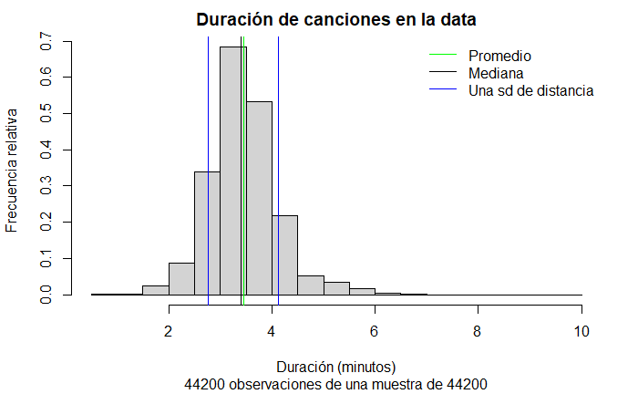

```r
legend("topright",
       legend = c ("Promedio", "Mediana", "Una sd de distancia"),
       col = c ("green", "black", "blue"),
       lty = c (1, 1, 1),
       bty = "n"
       )
```

```r
boxplot (R$Duration_Minutos,
         varwidth = TRUE,
         border = rgb (0, 0, 0, 0.2),
         pch = 20,
         horizontal=TRUE,
         main = "Duración de canciones en la data",
         xlab = "Duración (minutos)",
         sub = paste(sum (!is.na (R$Rank)), "observaciones de una muestra de", nrow (R))
         )
abline (v = c (mean(R$Duration_Minutos, na.rm = TRUE)),
        col = c ("blue"),
        lty = c (1)
        )
```

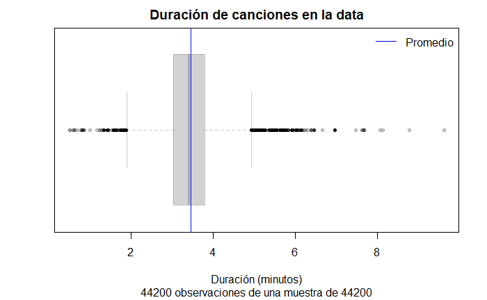

```r
legend ("topright",
       legend = c ("Promedio"),
       col = c ("blue"),
       lty = c (1),
       bty = "n"
       )
```

```r
cat ("Promedio de duración de canciones en la data (minutos):", mean (R$Duration_Minutos, na.rm = TRUE), "\n\nMediana de duración canciones en la data (minutos):", median (R$Duration_Minutos, na.rm = TRUE))
```

```
Promedio de duración de canciones en la data (minutos): 3.449862

Mediana de duración canciones en la data (minutos): 3.405767
```

En el histograma **“Duración de canciones en la data”** vemos que los datos son **aproximadamente simétricos**, dado que, el promedio y la mediana son **aproximadamente iguales**.

### Descriptores numéricos asociados a la variable **Duration_Minutos**

```r
Describir (R$Duration_Minutos)
```

```
Promedio: 3.449862

Mediana: 3.405767

Nº de modas: 1

Desviación estándar: 0.6805321

Rango: 9.117767

Rango intercuartil: 0.7593833

Cuartiles

 1.º Cuartil: 3.031883
 2.º Cuartil: 3.405767
 3.º Cuartil: 3.791267
 4.º Cuartil: 9.619983

Mínimo: 0.5022167

Máximo: 9.619983

Moda:
3.52443333333333
             218
```

- La **mayor duración de una canción en la data** es: 9.619983 (minutos).
- La **menor duración de una canción en la data** es: 0.5022167 (minutos).
- La **variable Duration_Minutos** posee 1 moda (unimodal).
- Al menos **25% de las canciones en la data** tiene una duración menor o igual a 3.031883 (minutos) o al menos **75% de las canciones en la data** una tiene duración mayor o igual a 3.031883 (minutos).
- Al menos **50% de las canciones en la data** una tiene duración menor o igual a 3.405767 (minutos) o al menos **50% de las canciones en la data** una tiene duración mayor o igual a 3.405767 (minutos).
- Al menos **75% de las canciones en la data** tiene una duración menor o igual a 3.791267 (minutos) o al menos **25% de las canciones en la data** tiene una duración mayor o igual a 3.791267 (minutos).

```r
hist ((R$Streams / 1000000),
      prob = TRUE,
      main = "Streams de canciones en la data",
      xlab = "Streams (millones)",
      ylab = "Frecuencia relativa",
      sub = paste(sum (!is.na (R$Streams)), "observaciones de una muestra de", nrow (R))
      )
abline (v = c (mean ((R$Streams / 1000000), na.rm = TRUE),
               median ((R$Streams / 1000000), na.rm = TRUE),
               mean ((R$Streams / 1000000), na.rm = TRUE) - sd ((R$Streams / 1000000), na.rm = TRUE),
               mean ((R$Streams / 1000000), na.rm = TRUE) + sd ((R$Streams / 1000000), na.rm = TRUE)),
        col = c ("green", "black", "blue", "blue"),
        lty = c (1, 1, 1, 1)
        )
```

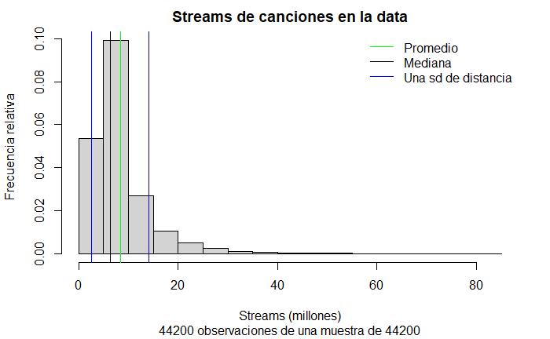

```r
legend("topright",
       legend = c ("Promedio", "Mediana", "Una sd de distancia"),
       col = c ("green", "black", "blue"),
       lty = c (1, 1, 1),
       bty = "n"
       )
```

```r
boxplot ((R$Streams / 1000000),
         varwidth = TRUE,
         border = rgb (0, 0, 0, 0.2),
         pch = 20,
         horizontal=TRUE,
         main = "Streams de canciones en la data",
         xlab = "Streams (millones)",
         sub = paste(sum (!is.na (R$Streams)), "observaciones de una muestra de", nrow (R))
         )
abline (v = c (mean((R$Streams / 1000000), na.rm = TRUE)),
        col = c ("blue"),
        lty = c (1)
        )
```

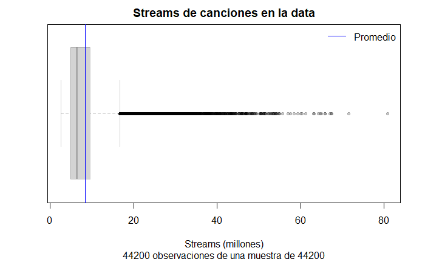

```r
legend ("topright",
       legend = c ("Promedio"),
       col = c ("blue"),
       lty = c (1),
       bty = "n"
       )
```

```r
cat ("Promedio de streams en la data (millones):", mean ((R$Streams / 1000000), na.rm = TRUE), "\n\nMediana de streams en la data (millones):", median ((R$Streams / 1000000), na.rm = TRUE))
```

```
Promedio de streams en la data (millones): 8.350751

Mediana de streams en la data (millones): 6.290181
```

En el histograma **“Streams de canciones en la data”** vemos que los datos son **sesgados a la derecha**, dado que, el promedio está a la derecha de la mediana.

### Descriptores numéricos asociados a la variable **Streams**

```r
Describir (R$Streams)
```

```
Promedio: 8350751

Mediana: 6290181

Nº de modas: 96

Desviación estándar: 5825349

Rango: 78238886

Rango intercuartil: 4691682

Cuartiles

 1.º Cuartil: 4921201
 2.º Cuartil: 6290181
 3.º Cuartil: 9612882
 4.º Cuartil: 80764045

Mínimo: 2525159

Máximo: 80764045

Moda:
X
 3122661  3148635  3365795  3522279  3739847  3988644  4004612  4049374  4161453  4166006  4272511  4385829  4392529  4400112  4412014  4425610  4448525
       2        2        2        2        2        2        2        2        2        2        2        2        2        2        2        2        2
 4484454  4490995  4562521  4567003  4603499  4614229  4617075  4654803  4687464  4708529  4733401  4786547  4788019  4795748  4829929  4853397  4881924
       2        2        2        2        2        2        2        2        2        2        2        2        2        2        2        2        2
 4894401  4900006  4940975  4979813  4994037  5012906  5033602  5053800  5085295  5089970  5177796  5213045  5215451  5220504  5241737  5242750  5308399
       2        2        2        2        2        2        2        2        2        2        2        2        2        2        2        2        2
 5311673  5322598  5380466  5458423  5463387  5524859  5561860  5567530  5599804  5602168  5623279  5667946  5677148  5793670  5798744  5839176  5849750
       2        2        2        2        2        2        2        2        2        2        2        2        2        2        2        2        2
 5864755  5903165  5937520  6040454  6051817  6133855  6137178  6448953  6457029  6665424  6677644  6800811  7109808  7161646  7449196  7463975  7486445
       2        2        2        2        2        2        2        2        2        2        2        2        2        2        2        2        2
 7530019  7634818  8285363  9213838  9542575 11002831 11670805 12707039 12730025 18477082 18936010
       2        2        2        2        2        2        2        2        2        2        2
```

La variable **Streams** es del tipo numérica discreta, pero dada la situación planteada, se comportará como variable numérica continua. Su rango es tan grande que resulta improbable que los valores se repitan fácilmente, la moda deja de ser relevante en este caso. Al ser muchas las modas, dejan de ser **interesantes**. En el estudio de los **Ranking 200 Charts Weekly Global (2017-2021)**, se está estudiando una zona donde ocurren cosas atípicas por construcción.

- El **mayor Nº de streams de una canción en la data** es: 80764045.
- El **menor Nº de streams de una canción en la data** es: 2525159.
- La **variable Streams** posee 96 modas. Este dato no es interesante, dado que, las modas **no son pocas**.
- Al menos **25% de las canciones en la data** tiene un Nº de streams menor o igual a 4921201 o al menos **75% de las canciones en la data** tiene un Nº de streams mayor o igual a 4921201.
- Al menos **50% de las canciones en la data** tiene un Nº de streams menor o igual a 6290181 o al menos **50% de las canciones en la data** tiene un Nº de streams mayor o igual a 6290181.
- Al menos **75% de las canciones en la data** tiene un Nº de streams menor o igual a 9612882 o al menos **25% de las canciones en la data** tiene un Nº de streams mayor o igual a 9612882.

```r
hist ((R$Artist_Followers / 1000000),
      main = "Nº de seguidores de artistas en la data",
      xlab = "Seguidores (millones)",
      ylab = "Frecuencia relativa",
      sub = paste(sum (!is.na (R$Artist_Followers)), "observaciones de una muestra de", nrow (R))
      )
abline (v = c (mean ((R$Artist_Followers / 1000000), na.rm = TRUE),
               median ((R$Artist_Followers / 1000000), na.rm = TRUE),
               mean ((R$Artist_Followers / 1000000), na.rm = TRUE) - sd ((R$Artist_Followers / 1000000), na.rm = TRUE),
               mean ((R$Artist_Followers / 1000000), na.rm = TRUE) + sd ((R$Artist_Followers / 1000000), na.rm = TRUE)),
        col = c ("green", "black", "blue", "blue"),
        lty = c (1, 1, 1, 1)
        )
```

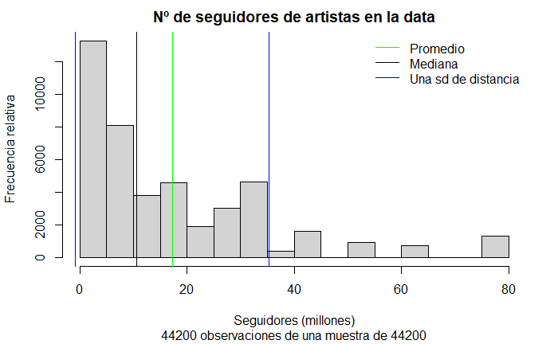

```r
legend("topright",
       legend = c ("Promedio", "Mediana", "Una sd de distancia"),
       col = c ("green", "black", "blue"),
       lty = c (1, 1, 1),
       bty = "n"
       )
```

```r
boxplot (((R$Artist_Followers / 1000000)),
         varwidth = TRUE,
         border = rgb (0, 0, 0, 0.2),
         pch = 20,
         horizontal=TRUE,
         main = "Nº de seguidores de artistas en la data",
         xlab = "Seguidores (millones)",
         sub = paste(sum (!is.na (R$Artist_Followers)), "observaciones de una muestra de", nrow (R))
         )
abline (v = c (mean((R$Artist_Followers / 1000000), na.rm = TRUE)),
        col = c ("blue"),
        lty = c (1)
        )
```

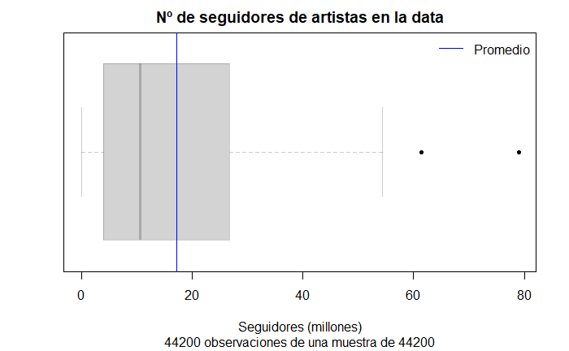

```r
legend ("topright",
       legend = c ("Promedio"),
       col = c ("blue"),
       lty = c (1),
       bty = "n"
       )
```

```r
cat ("Promedio de seguidores de artistas en la data (millones):", mean ((R$Artist_Followers / 1000000), na.rm = TRUE), "\n\nMediana de seguidores de artistas en la data (millones):", median ((R$Artist_Followers / 1000000), na.rm = TRUE))
```

```
Promedio de seguidores de artistas en la data (millones): 17.23903

Mediana de seguidores de artistas en la data (millones): 10.65384
```

En el histograma **“Nº de seguidores de artistas en la data”** vemos que los datos son **sesgados a la derecha**, dado que, el promedio está a la derecha de la mediana.

### Descriptores numéricos asociados a la variable **Artist_Followers**

```r
Describir (R$Artist_Followers)
```

```
Promedio: 17239028

Mediana: 10653835

Nº de modas: 1

Desviación estándar: 18023407

Rango: 78967863

Rango intercuartil: 22828275

Cuartiles

 1.º Cuartil: 3963838
 2.º Cuartil: 10653835
 3.º Cuartil: 26792113
 4.º Cuartil: 78967872

Mínimo: 9

Máximo: 78967872

Moda:
78967872
    1320
```

- El **mayor Nº de seguidores de un artista en la data** es: 78967872.
- El **menor Nº de seguidores de un artista en la data** es: 9.
- La **variable Artist_Followers** posee 1 moda (unimodal).
- Al menos **25% de los artistas en la data** tiene un Nº de seguidores menor o igual a 3963838 o al menos **75% de los artistas en la data** tiene un Nº de seguidores mayor o igual a 3963838.
- Al menos **50% de los artistas en la data** tiene un Nº de seguidores menor o igual a 10653835 o al menos **50% de los artistas en la data** tiene un Nº de seguidores mayor o igual a 10653835
- Al menos **75% de los artistas en la data** tiene un Nº de seguidores menor o igual a 26792113 o al menos **25% de los artistas en la data** tiene un Nº de seguidores mayor o igual a 26792113.

# Datos de interés

- La **canción con mayor duración en los Top 200 Charts Weekly Global (2017-2021)**:

```r
R$Track [R$Duration_Minutos == max (R$Duration_Minutos)]
```

```
[1] "Venice Bitch"
```

- La **canción con menor duración en los Top 200 Charts Weekly Global (2017-2021)**:

```r
R$Track [R$Duration_Minutos == min (R$Duration_Minutos)]
```

```
[1] "Alfred - Interlude"
```

- La **canción con mayor Nº de streams en los Top 200 Charts Weekly Global (2017-2021)**:

```r
R$Track [R$Streams == max (R$Streams)]
```

```
[1] "drivers license"
```

- Los **géneros con mayor Nº de apariciones en los Top 200 Charts Weekly Global (2017-2021)**:

```r
sort(decreasing =TRUE,table(R$Artist_Genres))[1]
```

```
['pop', 'uk pop']
             1576
```

- Los **géneros con menor Nº de apariciones en los Top 200 Charts Weekly Global (2017-2021)**:

```r
sort(decreasing =FALSE,table(R$Artist_Genres)) [1]
```

```
['adult standards', 'christmas instrumental', 'jazz trio']
                                                         1
```

- **El artista con menor Nº de seguidores en los Top 200 Charts Weekly Global (2017-2021)**:

```r
unique (R$Artist [R$Artist_Followers == min (R$Artist_Followers)])
```

```
[1] "Trío Los Josefinos"
```

- La **canción con mayor Nº de apariciones en los Top 200 Charts Weekly Global (2017-2021)**:

```r
sort(decreasing =TRUE,table(R$Track))[1]
```

```
Say You Won't Let Go
                 218
```

# Análisis del artista Ed Sheeran

Ed Sheeran es el artista más destacado en los Top 200 Charts Weekly Global (2017-2021), dado que, posee:

- el **mayor Nº de apariciones en los Top 200 Charts Weekly Global (2017-2021)**:

```r
sort(decreasing =TRUE,table(R$Artist)) [1]
```

```
Ed Sheeran
      1320
```

- el **mayor Nº de seguidores en los Top 200 Charts Weekly Global (2017-2021)**:

```r
unique (R$Artist [R$Artist_Followers == max (R$Artist_Followers)])
```

```
[1] "Ed Sheeran"
```

```r
max (R$Artist_Followers)
```

```
[1] 78967872
```

- el **álbum con mayor Nº de apariciones en los Top 200 Charts Weekly Global (2017-2021)**:

```r
sort(decreasing =TRUE,table(R$Album_Name))[1]
```

```
÷ (Deluxe)
       728
```

- La canción con mayor **Nº de streams de Ed Sheeran en los Top 200 Charts Weekly Global (2017-2021)**:

```r
R$Track [R$Streams == max (R$Streams [R$Artist == "Ed Sheeran"], na.rm = TRUE)]
```

```
[1] "Shape of You"
```

- La canción de Ed Sheeran con **mayor Nº de apariciones en los Top 200 Charts Weekly Global (2017-2021)** :

```r
sort (decreasing = TRUE, table (R$Track [R$Artist == "Ed Sheeran"])) [1]
```

```
Shape of You
         217
```

```r
plot(R$Week [R$Artist == "Ed Sheeran"],
     (R$Streams [R$Artist == "Ed Sheeran"] / 1000000),
     pch = 20,
     col = rgb(0, 0, 0, 0.2),
     main = "Apariciones del artista Ed Sheeran en los Top 200",
     xlab = "Tiempo (años)",
     ylab = "Streams (millones)",
     sub = paste(sum (!is.na (R$Week [R$Artist == "Ed Sheeran"])), "observaciones de una muestra de", nrow (R))
     )
abline(h = mean((R$Streams [R$Artist == "Ed Sheeran"] / 1000000), na.rm = TRUE),
       lty = 2,
       col = "black"
       )
```

```r
points (R$Week [R$Track == "Shape of You"],
        (R$Streams [R$Track == "Shape of You"] / 1000000),
        pch = 20,
        col = "lightblue"
        )
points (R$Week [R$Track == "Perfect"],
        (R$Streams [R$Track == "Perfect"] / 1000000),
        pch = 20,
        col = "blue"
        )
```

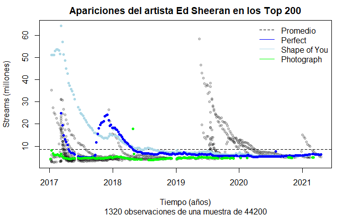

```r
points (R$Week [R$Track == "Photograph"],
        (R$Streams [R$Track == "Photograph"] / 1000000),
        pch = 20,
        col = "green"
        )
legend("topright",
       legend = c ("Promedio", "Perfect", "Shape of You", "Photograph"),
       col = c ("black", "blue", "lightblue", "green"),
       lty = c (2, 1, 1, 1),
       bty = "n"
       )
```

En el gráfico **“Apariciones del artista Ed Sheeran en los Top 200”** vemos las apariciones del artista **Ed Sheeran** con una música y su álbum correspondiente en los Top 200 Charts Weekly Global (2017-2021). Notamos que el artista **Ed Sheeran** fue más popular y escuchado entre los años 2017 - 2018, así como, entre los años 2019 - 2020. Se observa picos en la gráfica, que coinciden con la fecha cuando el artista **Ed Sheeran** lanzó nuevos álbumes o canciones.

En el gráfico también podemos ver la **evolución** de algunas canciones del artista **Ed Sheeran**, como: **“Perfect”, “Shape of You”, “Photograph”**.

# Variables aleatorias

[figure not shown]

## **Streams1** como variable aleatoria discreta con distribución de Bernoulli

Se define la variable **Streams1** como una **variable aleatoria discreta**, a partir de la variable **Streams**, donde un **Éxito (1 o TRUE)** se define cuando la variable Streams es mayor que el menor Nº de streams que obtuvo una canción que alcanzó el ranking 1 y un **Fracaso (0 o FALSE)** se define cuando la variable Streams es menor que el menor Nº de streams que obtuvo una canción que alcanzó el ranking 1.

Para esto, se necesita el dato del menor Nº de streams que obtuvo una canción que llegó a estar en el ranking 1:

```r
min (R$Streams [R$Rank == 1])
```

```
[1] 25734078
```

Con ello se puede realizar el siguiente gráfico de barras:

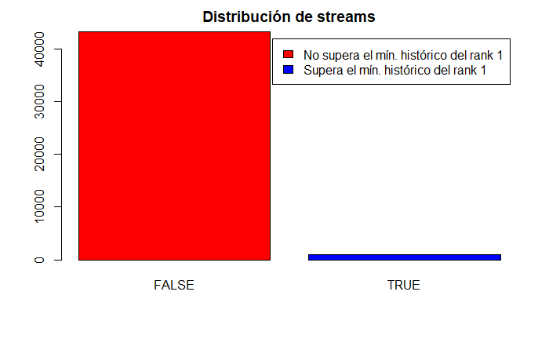

```r
barplot ( table (R$Streams > min (R$Streams [R$Rank==1])),
          col=c("red","blue"),
          main="Distribución de streams",
          legend.text = c ("No supera el mín. histórico del rank 1",
                           "Supera el mín. histórico del rank 1")
          )
```

El Nº total de **Fracasos** y **Éxitos** son respectivamente:

```r
table (R$Streams > min (R$Streams [R$Rank==1]))
```

```
FALSE  TRUE
43246   954
```

Se puede modelar como una **distribución de Bernoulli**, siendo la probabilidad:

```r
length (R$Streams [R$Streams > min (R$Streams [R$Rank == 1])]) / length (R$Streams)
```

```
[1] 0.02158371
```

Por lo tanto, podemos modelar la variable como una **distribución de Bernoulli. X ~ Ber(0.02158371)**

## **Artist_Followers1** como variable aleatoria discreta con distribución de Bernoulli

Se define la variable **Artist_Followers1** como una **variable aleatoria discreta**, a partir de la variable **Artist_Followers**, donde un **Éxito (1 o TRUE)** se define cuando la variable Artist_Followers supera el menor Nº de seguidores que obtuvo un artista que alcanzó el ranking 1 y un **Fracaso (0 o FALSE)** se define cuando la variable Artist_Followers **no** supera el menor Nº de seguidores que obtuvo un artista que alcanzó el ranking 1.

Para esto, se necesita el dato del menor Nº de seguidores que obtuvo el artista que llegó a estar en el ranking 1:

```r
min (R$Artist_Followers [R$Rank == 1])
```

```
[1] 87855
```

Con ello se puede realizar el siguiente gráfico de barras:

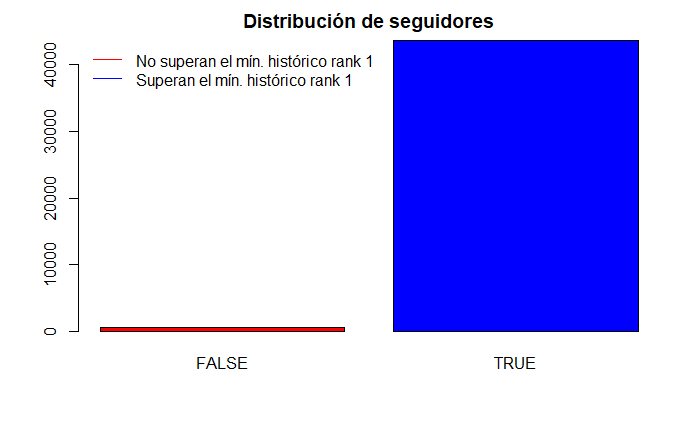

```r
barplot ( table (R$Artist_Followers > min (R$Artist_Followers [R$Rank==1])),
          col=c("red","blue"),
          main="Distribución de seguidores"
          )
legend("topleft",
       legend = c ("No superan el mín. histórico rank 1","Superan el mín. histórico rank 1"),
       col = c ("red", "blue"),
       lty = c (1, 1),
       bty = "n"
       )
```

El Nº total de **Fracasos** y **Éxitos** son respectivamente:

```r
table (R$Artist_Followers > min (R$Artist_Followers [R$Rank==1]))
```

```
FALSE  TRUE
  511 43689
```

Se puede modelar como una **distribución de Bernoulli**, siendo la probabilidad:

```r
length (R$Artist_Followers [R$Artist_Followers > min (R$Artist_Followers [R$Rank==1])]) / length (R$Artist_Followers)
```

```
[1] 0.9884389
```

Por lo tanto, podemos modelar la variable como una **distribución de Bernoulli. X ~ Ber(0.9884389)**

## **Duration_Minutos** como variable aleatoria continua con distribución normal

Al buscar una forma de expresar su distribución, la distribución que hemos encontrado más parecida es la **distribución normal “X ~ N()”**, esto al ver que al superponer la **gráfica de duración** y la **función de distribución normal** (con sus límites, media y desviación estándar), es notable una similitud que consideramos suficiente para aproximar la variable duración a una distribución normal.

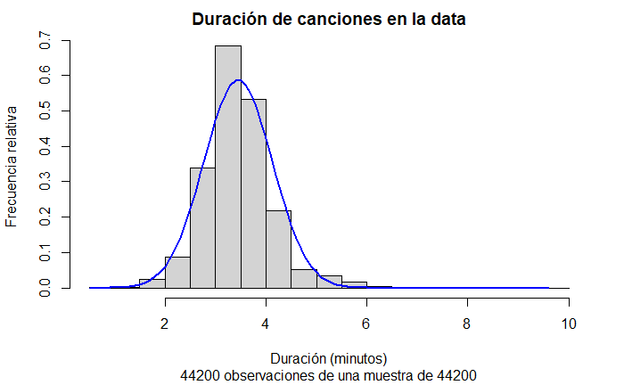

```r
hist (R$Duration_Minutos,
      prob = TRUE,
      main = "Duración de canciones en la data",
      xlab = "Duración (minutos)",
      ylab = "Frecuencia relativa",
      sub = paste(sum (!is.na (R$Duration_Minutos)), "observaciones de una muestra de", nrow (R))
      )
x <- seq(0.5022167, 9.619983, 0.1)

lines(x,
      dnorm(x, mean = 3.449862, sd = 0.680),
      col = "blue",
      lty = 1,
      lwd = 2)
```

```r
spec (R)
```